# Asset Allocation EUR — simulation and Expected Shortfall

Portfolio choice across four euro-denominated asset classes — government bonds, investment-grade and high-yield corporate bonds and European equity — each represented by a UCITS ETF quoted on Xetra, with daily prices from Yahoo Finance (downloaded with `quantmod`). Prices are adjusted for distributions, so each series is a proxy for the total-return index of its asset class.

The optimiser is validated against an independent reference implementation of the same method on identical scenarios (see the test suite); full runs of the two differ only within Monte Carlo error, because they draw different scenarios.

The pipeline:

1. download adjusted close prices (cached on disk) and compute daily log returns;
2. bootstrap whole historical days (or weeks, see `RETURN_FREQ`) over `HORIZON_DAYS` business days, `N_SCENARIOS` times, to obtain the joint distribution of the four asset returns at the horizon;
3. measure risk by the **Expected Shortfall** (ES) at `ES_LEVEL`;
4. solve the **minimum-ES** portfolio, the **maximum return/ES ratio** portfolio and the **mean–ES frontier** exactly by linear programming;
5. draw a cloud of random portfolios to picture the feasible region;
6. show the distributions of the simulated returns at the horizon.

Conventions: returns are simple returns over the horizon; portfolios are buy-and-hold, with no rebalancing within the horizon; ES is reported as a positive number, a loss; the risk-free rate is a fixed annual constant (set in `RISK_FREE`) converted to the horizon; the minimum and maximum weight of each asset class are set in `BOUNDS`. Periods (days, or weeks) are resampled independently, each with the full historical cross-section, so correlations, fat tails and skew are those of the sample, while serial dependence between periods is not modelled. The random cloud is only illustrative: the optimal portfolios come from the linear programs.

## Setup

The code lives in the `R/` folder, one file per section of this notebook; `R/all.R` sources them in order. The packages used are `quantmod` (data), `Matrix` and `highs` (linear programs), `ggplot2`, `ggrepel` and `scales` (charts) and `jsonlite` (cache metadata).

```r
source("R/all.R")
```

### Parameters

All parameters are defined in `R/params.R`. `RETURN_FREQ` chooses whether the bootstrap resamples historical days (`"daily"`) or whole weeks (`"weekly"`, the sum of the daily log returns of each ISO week); the horizon stays in business days and is converted to the number of weeks to resample (12 for 60 days; holidays make a resampled week slightly shorter than five trading days, so 12 weeks cover about 58 of them). `BOUNDS` sets the minimum and maximum weight of each asset class and is restated below so it can be edited here; assets not listed get `c(0, 1)`, and the bounds are validated when the Run chunk starts. After changing anything, re-knit the notebook from the top. The random generators are seeded inside the simulation and the cloud (`SIM_SEED`, `CLOUD_SEED`), so re-running the Run chunk reproduces the same scenarios.

```r
# Minimum and maximum weight per asset class (fraction of the portfolio).
# Assets not listed get c(0, 1).
BOUNDS <- list("Euro Govt"     = c(0, 1),
               "Euro Corp IG"  = c(0, 1),
               "Euro Corp HY"  = c(0, 1),
               "Europe Equity" = c(0, 1))

# The other parameters, as defined in R/params.R.
str(list(NAMES = NAMES, START_DATE = START_DATE, HORIZON_DAYS = HORIZON_DAYS,
         RETURN_FREQ = RETURN_FREQ, N_SCENARIOS = N_SCENARIOS, ES_LEVEL = ES_LEVEL,
         N_RANDOM = N_RANDOM, DIRICHLET_ALPHA = DIRICHLET_ALPHA, N_FRONTIER = N_FRONTIER,
         RISK_FREE = RISK_FREE, SIM_SEED = SIM_SEED, CLOUD_SEED = CLOUD_SEED,
         CACHE_DIR = CACHE_DIR, CACHE_TTL_HOURS = CACHE_TTL_HOURS))
```

```
## List of 14
##  $ NAMES          : Named chr [1:4] "Euro Govt" "Euro Corp IG" "Euro Corp HY" "Europe Equity"
##   ..- attr(*, "names")= chr [1:4] "EUNH.DE" "EUN5.DE" "EUNW.DE" "EXSA.DE"
##  $ START_DATE     : chr "2010-01-01"
##  $ HORIZON_DAYS   : num 60
##  $ RETURN_FREQ    : chr "daily"
##  $ N_SCENARIOS    : num 10000
##  $ ES_LEVEL       : num 0.95
##  $ N_RANDOM       : num 3000
##  $ DIRICHLET_ALPHA: num 0.5
##  $ N_FRONTIER     : num 20
##  $ RISK_FREE      : num 0
##  $ SIM_SEED       : num 42
##  $ CLOUD_SEED     : num 7
##  $ CACHE_DIR      : chr "data/cache"
##  $ CACHE_TTL_HOURS: num 12
```

## Data

Prices are cached on disk as RDS files, keyed by universe and start date (`R/data.R`). Lookup order: fresh cache → download → stale cache → error.

Two rules keep the cache trustworthy:

- **Always refetch the full history, never append.** Yahoo restates the whole adjusted series after every dividend or split, so appending new rows to old ones would splice two different adjustment bases.
- **Only a complete download overwrites the cache.** A partial download must not turn a transient failure into a permanent one.

Series are aligned on common dates, so the sample starts at the youngest listing in the universe (the high-yield ETF, December 2010).

## Simulation

Bootstrap (`simulate_horizon_returns`, `R/simulation.R`): whole historical periods (days, or weeks when `RETURN_FREQ = "weekly"`) are resampled with replacement, so the cross-section of the four assets is preserved exactly as observed. Periods are drawn independently; with weekly returns the serial dependence inside each week is kept. The simple return at the horizon is `exp(sum of the resampled log returns) - 1`.

## Portfolio metrics

The portfolio return in each scenario is the weighted sum of the asset returns (buy-and-hold over the horizon). Expected shortfall (ES) at level alpha is the mean loss over the worst (1 - alpha) share of scenarios, reported as a positive number; when that share is not a whole number of scenarios the boundary scenario is weighted fractionally, so the value equals the linear-programming optimum exactly. The ratio of the expected excess return to the ES of the excess returns is the analogue of the Sharpe ratio (`R/metrics.R`).

## Optimisation

By Rockafellar and Uryasev, the ES at level alpha equals the minimum over zeta of zeta + mean(max(L - zeta, 0)) / (1 - alpha), where L is the loss in each scenario. Adding auxiliary variables u_s >= max(L_s - zeta, 0) turns this into a linear program in (w, zeta, u), which HiGHS (the `highs` package) solves exactly. The budget constraint sum(w) = 1, the per-asset bounds and an optional minimum expected return are all linear in w (`R/optimisation.R`).

The max-ratio portfolio is found with a single LP: the ES of excess returns is positively homogeneous in the weights, so the budget constraint can be replaced by a normalisation of the expected excess return, and the per-asset bounds become homogeneous linear constraints. Two preconditions are checked, each stopping with an error: some feasible portfolio must have a positive expected excess return, and the optimal ES of excess returns must be positive (otherwise the ratio is unbounded).

The efficient frontier is the set of min-ES portfolios for a grid of target returns, from the return of the min-ES portfolio up to 0.999 times the maximum attainable return under the bounds. Infeasible targets are skipped with a `[frontier]` message.

## Random portfolios

Random weights are drawn from a Dirichlet distribution, shifted so that the lower bounds hold by construction, and rejected when they break an upper bound (`R/cloud.R`). Each portfolio is evaluated on all scenarios. If fewer than 5 % of the first draw satisfy the bounds, a `[cloud]` message says so and the cloud stays small. The cloud only illustrates the feasible region: the optima come from the LPs.

## Plot

The chart (`plot_frontier`, `R/plots.R`) shows the random cloud, the min-ES frontier, the single assets, the two optimal portfolios and the allocation line from the risk-free point through the max-ratio portfolio, in the (ES, expected return) plane at the horizon. Beyond the max-ratio point the line would require borrowing at the risk-free rate: it is shown for reference only, since the optimisation is fully invested without leverage. A riskless return `rf_h` has Expected Shortfall `−rf_h`, so the risk-free point sits at `(−rf_h, rf_h)` (at zero for `RISK_FREE = 0`). Single assets are plotted as reference points even when a 100 % position lies outside `BOUNDS`.

## Distributions at the horizon

Simulated returns at the horizon for each asset and for the two optimal portfolios. The table gives moments and tail measures; the histograms carry a normal fit, so the fat tails inherited from the bootstrap are visible. The tail columns are named after `ES_LEVEL` (`var_95`, `es_95` at 95 %): `var_95` is a quantile of returns, usually negative, while `es_95` is a positive loss.

## Run

Download, simulate, optimise and plot, using the parameters above.

```r
data <- get_prices_and_logret(TICKERS)
```

```
## [data] cache (5.8h old)
```

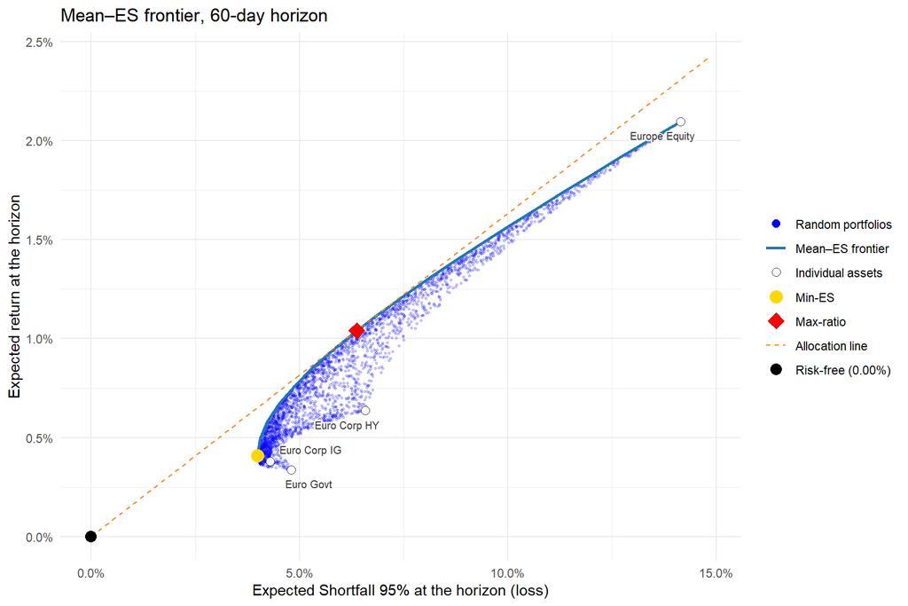

```r
prices <- data$prices
logret <- data$logret
colnames(logret) <- unname(NAMES[colnames(logret)])  # asset-class labels from here on
logret <- aggregate_logret(logret, RETURN_FREQ)       # daily (unchanged) or weekly
horizon <- horizon_periods(HORIZON_DAYS, RETURN_FREQ) # periods to resample
h_label <- horizon_label(HORIZON_DAYS, RETURN_FREQ)   # for the chart titles
b <- check_bounds(BOUNDS, colnames(logret))
lo <- b$lo
hi <- b$hi
rf_h <- exp(RISK_FREE * HORIZON_DAYS / 252) - 1

scenarios <- simulate_horizon_returns(logret, horizon, N_SCENARIOS, SIM_SEED)
asset_ret <- colMeans(scenarios)
asset_es <- apply(scenarios, 2, expected_shortfall, level = ES_LEVEL)

rand <- sample_random_portfolios(scenarios, ES_LEVEL, lo, hi, N_RANDOM, DIRICHLET_ALPHA, CLOUD_SEED)
min_es <- min_es_portfolio(scenarios, ES_LEVEL, lo, hi, rf_h)
max_ratio <- max_ratio_portfolio(scenarios, ES_LEVEL, lo, hi, rf_h)
frontier <- build_es_frontier(scenarios, ES_LEVEL, lo, hi, rf_h, N_FRONTIER,
                              min_es$ret, 0.999 * max_return(scenarios, lo, hi))

p_frontier <- plot_frontier(rand, frontier$es, frontier$ret, min_es, max_ratio,
                            asset_ret, asset_es, rf_h, h_label, ES_LEVEL)
print(p_frontier)
```

```r
dir.create("figures", showWarnings = FALSE)
ggplot2::ggsave("figures/frontier.png", p_frontier, width = 9, height = 6, dpi = 150, bg = "white")

level_pct <- format(ES_LEVEL * 100)  # "95", "97.5"
cat(sprintf("Sample: %s to %s, %d %s returns, %d assets | horizon %d %s, %s scenarios\n",
            rownames(prices)[1], rownames(prices)[nrow(prices)], nrow(logret), RETURN_FREQ,
            ncol(prices), horizon, if (RETURN_FREQ == "daily") "days" else "weeks",
            formatC(N_SCENARIOS, format = "d", big.mark = ",")))
```

```
## Sample: 2010-12-15 to 2026-10-30, 4030 daily returns, 4 assets | horizon 60 days, 10,000 scenarios
```

```r
cat(sprintf("Min-ES:     E[R]=%.2f%%  ES%s=%.2f%%  ratio=%.3f\n",
            100 * min_es$ret, level_pct, 100 * min_es$es, min_es$ratio))
```

```
## Min-ES:     E[R]=0.41%  ES95=3.99%  ratio=0.102
```

```r
cat(sprintf("Max-ratio:  E[R]=%.2f%%  ES%s=%.2f%%  ratio=%.3f\n",
            100 * max_ratio$ret, level_pct, 100 * max_ratio$es, max_ratio$ratio))
```

```
## Max-ratio:  E[R]=1.04%  ES95=6.37%  ratio=0.163
```

```r
knitr::kable(weights_table(min_es, max_ratio), caption = "Weights (%)")
```

Weights (%)

|  | Min-ES | Max-ratio |
| --- | --- | --- |
| Euro Govt | 42.49 | 51.88 |
| Euro Corp IG | 42.40 | 8.34 |
| Euro Corp HY | 14.61 | 0.00 |
| Europe Equity | 0.49 | 39.78 |

### Table and histograms

```r
returns <- cbind(scenarios,
                 "Min-ES" = portfolio_scenarios(scenarios, min_es$w),
                 "Max-ratio" = portfolio_scenarios(scenarios, max_ratio$w))
stats <- horizon_stats(returns, ES_LEVEL)

#' Format every column as a percentage: two decimals, one for prob_loss.
as_percent <- function(df) {
  out <- df
  for (cn in names(df)) {
    out[[cn]] <- sprintf(if (cn == "prob_loss") "%.1f%%" else "%.2f%%", 100 * df[[cn]])
  }
  out
}
knitr::kable(as_percent(stats), align = "r")
```

|  | mean | median | std | var_95 | es_95 | prob_loss | min | max |
| --- | --- | --- | --- | --- | --- | --- | --- | --- |
| Euro Govt | 0.34% | 0.31% | 2.49% | -3.72% | 4.80% | 45.1% | -9.66% | 10.62% |
| Euro Corp IG | 0.38% | 0.43% | 2.03% | -2.99% | 4.29% | 41.0% | -11.70% | 9.03% |
| Euro Corp HY | 0.64% | 0.73% | 3.17% | -4.77% | 6.58% | 40.1% | -16.09% | 13.04% |
| Europe Equity | 2.10% | 1.87% | 8.11% | -11.11% | 14.14% | 40.3% | -28.34% | 46.46% |
| Min-ES | 0.41% | 0.43% | 2.00% | -2.90% | 3.99% | 40.8% | -10.61% | 9.17% |
| Max-ratio | 1.04% | 0.99% | 3.64% | -4.87% | 6.37% | 39.1% | -12.21% | 18.78% |

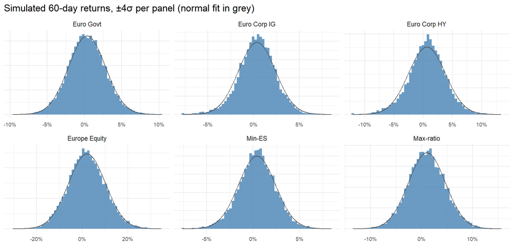

```r
p_dist <- plot_distributions(returns, h_label)
print(p_dist)
```

```r
ggplot2::ggsave("figures/distributions.png", p_dist, width = 9.6, height = 4.6, dpi = 150, bg = "white")
```